# vivid - quickstart guide

The aim of this guide is to give a brief introduction and explanation to the functions contained inside the `vivid` package. `vivid` (variable importance and variable interaction displays) is used for investigating relationships within a machine learning model fit. All of the visualisations in this vignette are highly customizable (see the long-form `vivid` vignette to see examples) and return `ggplot` objects which can be customized using the normal `ggplot` options.

Note: For the purposes of speed, the grid size (i.e., `gridSize` - the size of the gid on which the evaluations are made) and the number of rows subsetted (`nmax`) are small. This achieve more accurate results, incerease both the grid size and the number of rows used.

## Install instructions

Some of the plots used by `vivid` are built upon the `zenplots` package which requires the `graph` package from BioConductor. To install the `graph` and `zenplots` packages use:

`if (!requireNamespace("graph", quietly = TRUE)){`  
`install.packages("BiocManager")`  
`BiocManager::install("graph")`  
`}`  
`install.packages("zenplots")`

Now we can install and load `vivid` by using:

`install.packages("vivid")`

We then load the other required packages.

```r
library(vivid) # for visualisations
library(randomForest) # for model fit
library(ranger)       # for model fit
library(ggplot2)
```

# Section 1: Data and model fits

## Data used in this vignette:

The data used in the following examples is simulated from the Friedman benchmark problem 1[^1]. This benchmark problem is commonly used for testing purposes. The output is created according to the equation:

$$y = 10 sin(π x_1 x_2) + 20 (x_3 - 0.5)^2 +
10 x_4 + 5 x_5 + e$$

Create the data:

```r
set.seed(101)
genFriedman <- function(noFeatures = 10,
                        noSamples = 100,
                        sigma = 1) {
  # Set Values
  n <- noSamples # no of rows
  p <- noFeatures # no of variables
  e <- rnorm(n, sd = sigma)


  # Create matrix of values
  xValues <- matrix(runif(n * p, 0, 1), nrow = n) # Create matrix
  colnames(xValues) <- paste0("x", 1:p) # Name columns
  df <- data.frame(xValues) # Create dataframe


  # Equation:
  # y = 10sin(πx1x2) + 20(x3−0.5)^2 + 10x4 + 5x5 + ε
  y <- (10 * sin(pi * df$x1 * df$x2) + 20 * (df$x3 - 0.5)^2 + 10 * df$x4 + 5 * df$x5 + e)
  # Adding y to df
  df$y <- y
  df
}

myData <- genFriedman(noFeatures = 9, noSamples = 350, sigma = 1)
```

```r
set.seed(101)
fit <- randomForest(y ~ ., data = myData)
```

Next, we create the ‘vivi-matrix’, which will contain variable importance on the diagonal and variable interactions in the upper and lower triangle. This matrix can then be supplied to the `vivid` plotting functions.

```r
set.seed(101)
viFit <- vivi(
  fit = fit,
  data = myData,
  response = "y",
  gridSize = 10,
  importanceType = NULL,
  nmax = 100,
  reorder = TRUE,
  class = 1,
  predictFun = NULL
)
```

#Section 2: Visualizing the results

### Heatmap plot

To create a heatmap of the vivi-matrix, we use:

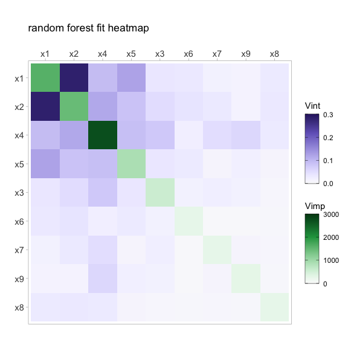

```r
viviHeatmap(mat = viFit) + ggtitle("random forest fit heatmap")
```

Fig 1.0: *Heatmap of a random forest fit displaying 2-way interaction strength on the off diagonal and individual variable importance on the diagonal. $x_1$ and $x_2$ show a strong interaction with $x_4$ being the most important for predicting $y$.*

### Network plot

To create a network graph of the vivi-matrix, we use:

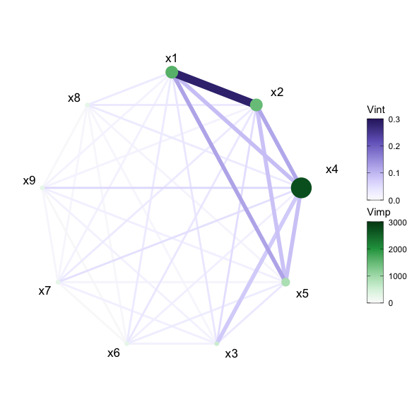

```r
viviNetwork(mat = viFit)
```

Fig 1.1: *Network plot of a random forest fit displaying 2-way interaction strength and individual variable importance. $x_1$ and $x_2$ show a strong interaction with $x_4$ being the most important for predicting $y$.*

### Generalized partial dependence pairs plot

In this plot we use a generalized pairs plot matrix style layout (which we call GPDP) to display partial dependence plots (PDPs) in the upper triangle, individual conditional exception curves (along with the aggregated 1-way partial dependence) on the diagonal and a scatterplot in the lower triangle.

To create the plot we supply the model fit to the plotting function.

```
#> Generating ice/pdp fits... waiting...
#> Finished ice/pdp
```

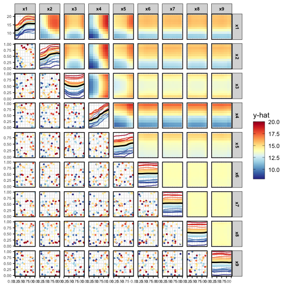

```r
set.seed(1701)
pdpPairs(data = myData, fit = fit, response = "y", nmax = 50, gridSize = 10)
```

Fig 1.3: *GPDP of a random forest fit on the Friedman data. From the plot we can see a clear interaction between $x_1$ and $x_2$. This can be seen in both the changing ICE curves and 2-way PDPs*

### Partial dependence ‘Zenplot’

For this plot, we calculate the bivariate partial dependence and display them in a *zenplots* layout, which we call (ZPDP). The ZPDP is based on graph Eulerians and focuses on key subsets. ‘Zenplots’ create a zigzag expanded navigation plot (‘zenplot’) of the partial dependence values. This results in an alternating sequence of two-dimensional plots laid out in a zigzag structure, as shown in Fig 4.0 below and can be used as a useful space-saving plot that displays the most influential variables.

```r
set.seed(1701)
pdpZen(data = myData, fit = fit, response = "y", nmax = 50, gridSize = 10)
```

```
#> Generating ice/pdp fits... waiting...
#> Finished ice/pdp
```

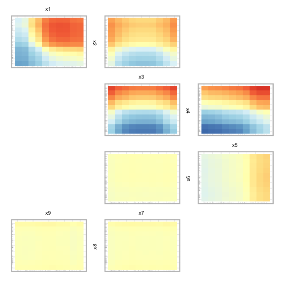

Fig 4.0: *ZPDP of a random forest fit on a subset of the Friedman data.*

In Fig 4.0, we can see PDPs laid out in a zigzag structure, with the most influential variable pairs displayed at the top. As we move down the plot, we also move down in influence of the variable pairs.

Using the `zpath` argument, we can filter out any interactions below a set value. `zpath` takes the vivi matrix as a function argument and then, using `cutoff`, we can filter out any interactions below the chosen value. For example:

```r
set.seed(1701)
zpath <- zPath(viv = viFit, cutoff = 0.1)
pdpZen(data = myData, fit = fit, response = "y", nmax = 50, gridSize = 10, zpath = zpath)
```

```
#> Generating ice/pdp fits... waiting...
#> Finished ice/pdp
```

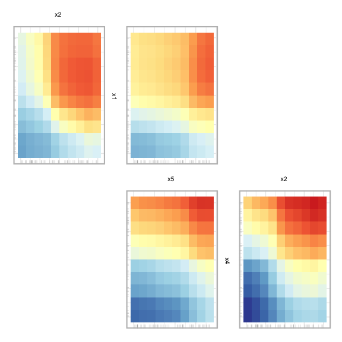

Fig 4.1: *ZPDP of a random forest fit on a subset of the Friedman data with a zpath of 0.1.*

# Section 3: Classification example

In this section, we briefly describe how to apply the above visualisations to a classification example using the `iris` data set.

To begin we fit a `ranger` random forest model with “Species” as the response and create the vivi matrix setting the category for classification to be “setosa” using `class`.

```r
set.seed(1701)
rfClassif <- ranger(Species ~ .,
  data = iris, probability = T,
  importance = "impurity"
)

set.seed(101)
viviClassif <- vivi(
  fit = rfClassif,
  data = iris,
  response = "Species",
  gridSize = 10,
  importanceType = NULL,
  nmax = 50,
  reorder = TRUE,
  class = "setosa",
  predictFun = NULL
)
```

```
#> Embedded impurity variable importance method used.
#> Calculating interactions...
```

Next we plot the heatmap and network plot of the iris data.

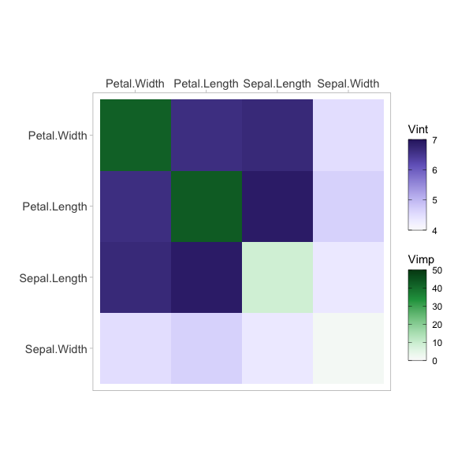

```r
set.seed(1701)
viviHeatmap(mat = viviClassif)
```

Fig 5.0: *Heatmap of random forest fit on the iris data.*

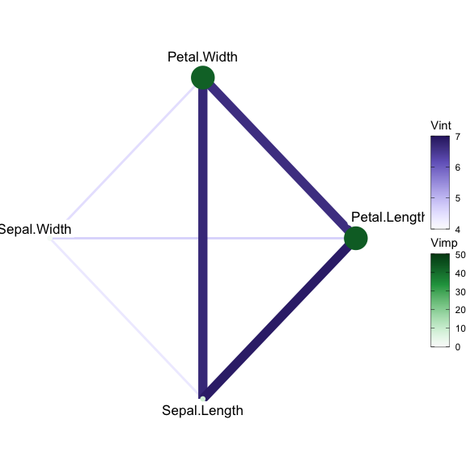

```r
set.seed(1701)
viviNetwork(mat = viviClassif)
```

Fig 5.1: *Network graph of random forest fit on the iris data.*

```
#> Generating ice/pdp fits... waiting...
#> Finished ice/pdp
```

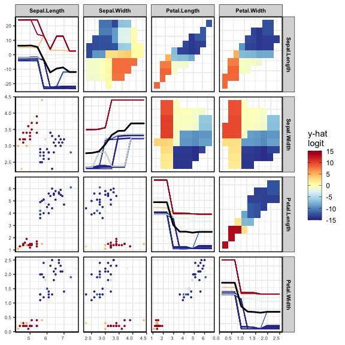

```r
set.seed(1701)
pdpPairs(data = iris, fit = rfClassif, response = "Species", class = "setosa", convexHull = T,  gridSize = 10, nmax = 50)
```

Fig 5.2 *GPDP of random forest fit on the iris data with extrapolated data removed.*

Finally, a ZPDP for the random forest fit on the iris data with extrapolated data removed:

```r
set.seed(1701)
pdpZen(data = iris, fit = rfClassif, response = "Species", class = "setosa", convexHull = T,  gridSize = 10, nmax = 50)
```

```
#> Generating ice/pdp fits... waiting...
#> Finished ice/pdp
```

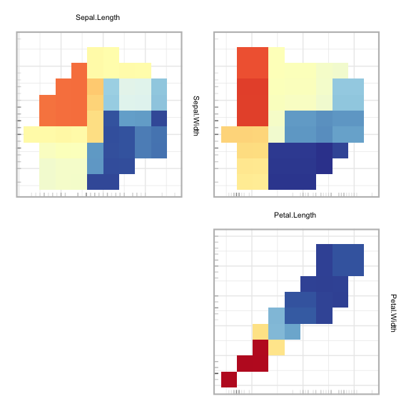

Fig 5.2 *ZPDP of random forest fit on the iris data with extrapolated data removed.*

[^1]: Friedman, Jerome H. (1991) Multivariate adaptive regression splines. The Annals of Statistics 19 (1), pages 1-67.